# SIG Results

Hanne Oberman

7-10-2021

# Reference Performance

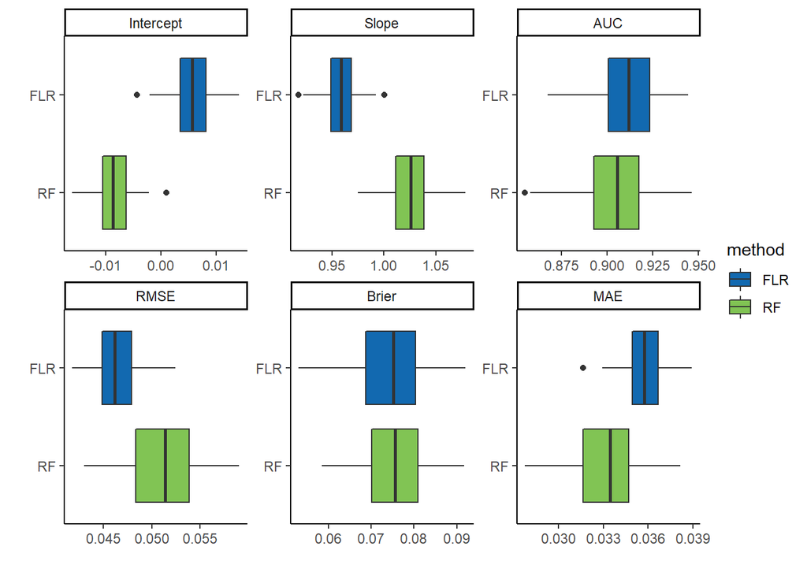

On complete data, the flexible logistics regression and random forest prediction models have equivalent calibration:

- FLR intercept closer to 0 than RF (0.006, -0.008, respectively);
- FLR slope further from 1 than RF (0.959, 1.025, respectively).

The flexible logistic regression prediction model has somewhat better discrimination than the random forest:

- FLR C-index higher than RF (0.911, 0.904, respectively).

# Simulation Results

## Calibration

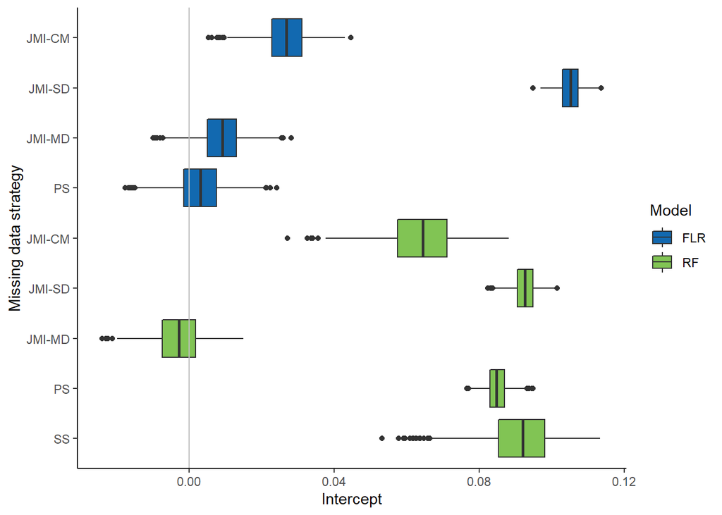

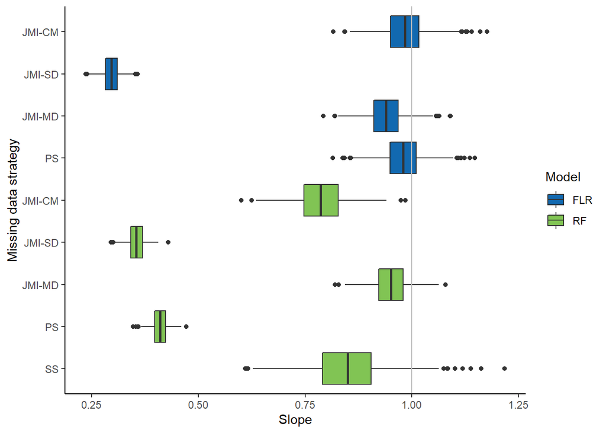

Aim: Intercept should be zero, slope should be one.

Summary:

- Best performance in terms of intercept: BOS+FLR, MDI+RF, MDI+FLR
- Worst performance in terms of intercept: SDI+FLR, SS+RF (wide range), SDI+RF, BOS+RF (CMI+RF = mixed bag)
- Best performance in terms of slope: BOS+FLR, CMI+FLR, MDI+RF and MDI+FLR
- Terrible performance in terms of slope: SDI+FLR, SDI+RF, BOS+RF

## AUC

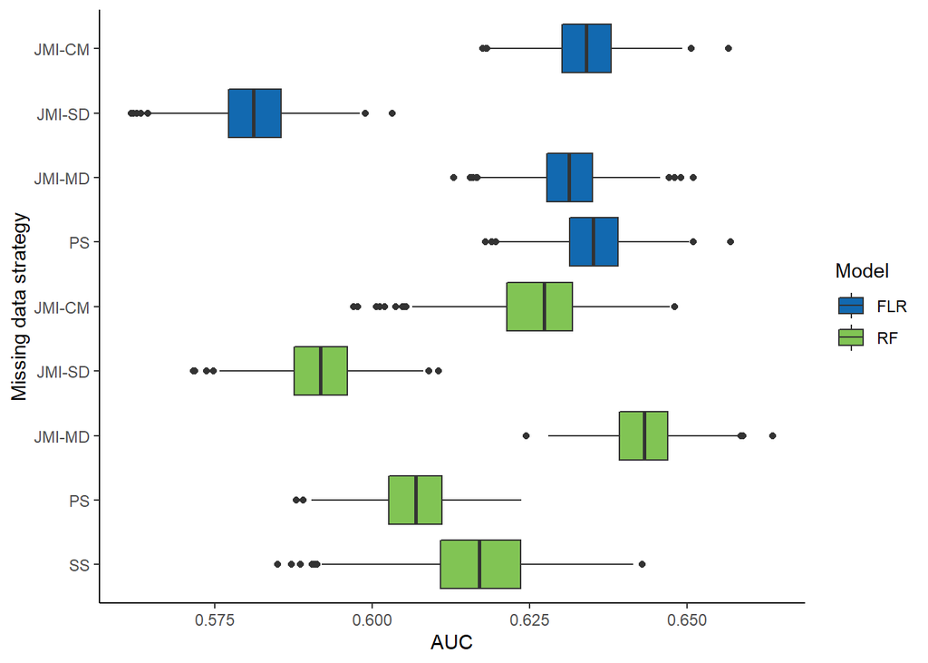

Aim: As close to one as possible. Method with the highest AUC has the best discrimination between patients with and without the outcome (Y).

## MAE

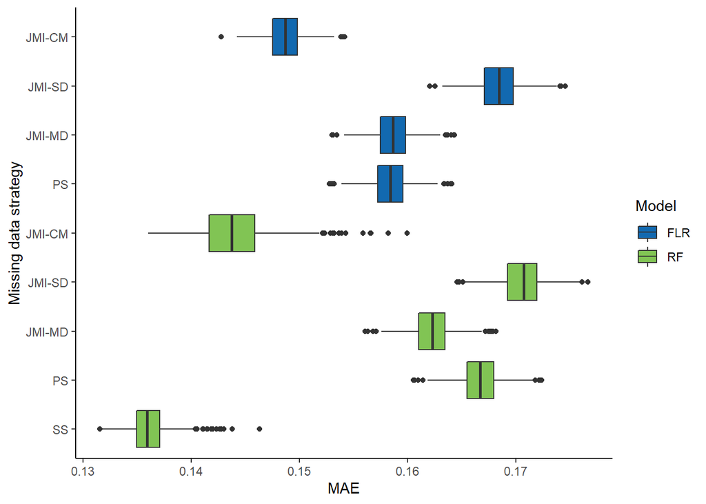

Aim: As close to zero as possible. Method with the lowest MAE has the best approximation of the true probability of Y.

## RMSE

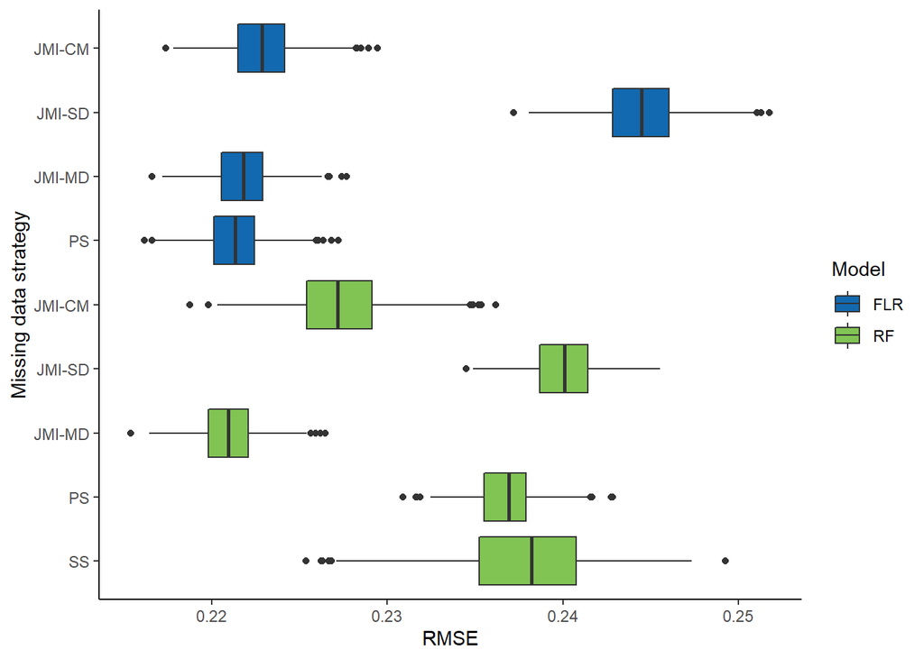

Aim: As close to zero as possible. Method with the lowest RMSE has best recovered the original probability of Y.

## Brier score

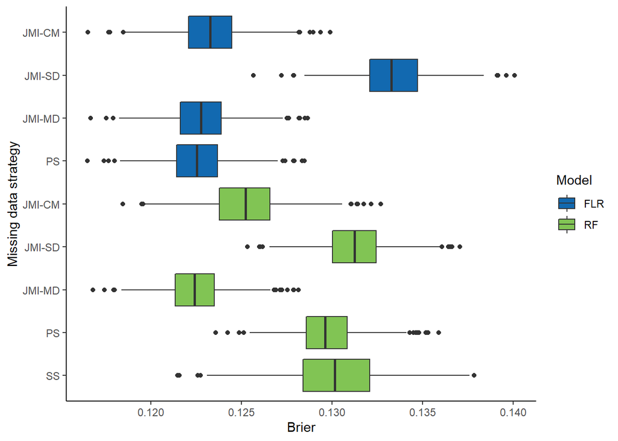

Aim: As close to zero as possible. Method with the lowest Brier score has best recovered the original observed Y.

## Full Figure

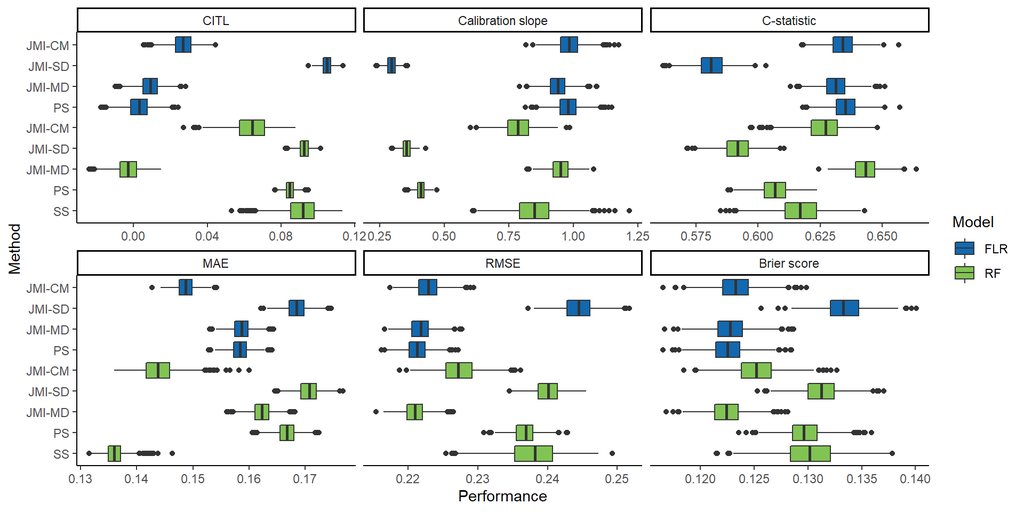

## Summary Table

| Model | Strategy | Intercept | Slope | AUC | RMSE | Brier | MAE |
| --- | --- | --- | --- | --- | --- | --- | --- |
| FLR | CMI | 0.027 | 0.985 | 0.634 | 0.223 | 0.123 | 0.149 |
| FLR | SDI | 0.105 | 0.297 | 0.581 | 0.244 | 0.133 | 0.168 |
| FLR | MDI | 0.009 | 0.941 | 0.631 | 0.222 | 0.123 | 0.159 |
| FLR | BOS | 0.003 | 0.981 | 0.635 | 0.221 | 0.123 | 0.158 |
| RF | CMI | 0.064 | 0.789 | 0.627 | 0.227 | 0.125 | 0.144 |
| RF | SDI | 0.093 | 0.355 | 0.592 | 0.240 | 0.131 | 0.171 |
| RF | MDI | -0.003 | 0.952 | 0.643 | 0.221 | 0.122 | 0.162 |
| RF | BOS | 0.085 | 0.410 | 0.607 | 0.237 | 0.130 | 0.167 |
| RF | SS | 0.091 | 0.851 | 0.617 | 0.238 | 0.130 | 0.136 |